# RRBS - BiSeq rTg4510 Part 1

Isabel Castanho (I.S.Castanho@exeter.ac.uk)

2020-06-04

**BiSeq** R/Bioconductor by K. Hebestreit et al.

[Bioconductor](https://bioconductor.org/packages/release/bioc/html/BiSeq.html)  
[User guide](https://bioconductor.org/packages/release/bioc/vignettes/BiSeq/inst/doc/BiSeq.pdf)  
[Manual](https://bioconductor.org/packages/release/bioc/manuals/BiSeq/man/BiSeq.pdf)  
[Paper](https://academic.oup.com/bioinformatics/article/29/13/1647/200453)

The package takes already aligned BS data from one or multiple samples.

## Import of Bismark’s methylation output files

```r
sample_names <- rownames(coldata)
infile <- list.files("/gpfs/ts0/projects/Research_Project-191406/isabel/RRBS_new/BismarkOutput/rTg4510/",
                     pattern = "bismark.cov.gz",
                     all.files=TRUE,
                     full.names=TRUE,
                     recursive=FALSE,
                     ignore.case=FALSE,
                     include.dirs=FALSE,
                     no..=TRUE)

# rrbs <- readBismark(files = infile, colData = coldata)
# # files: A character pointing to cov files created by Bismark’s methylation_extractor and bismark2bedGraph
# # colData: Samples’ names plus additional sample information ascharacter,data.frameorDataFrame
# # value: A BSrawobject storing coverage and methylation information
#
# save(rrbs,
#        file = "/gpfs/ts0/projects/Research_Project-191406/isabel/RRBS_new/biseq_rTg4510.RData")
```

## Quality control

### Coverage

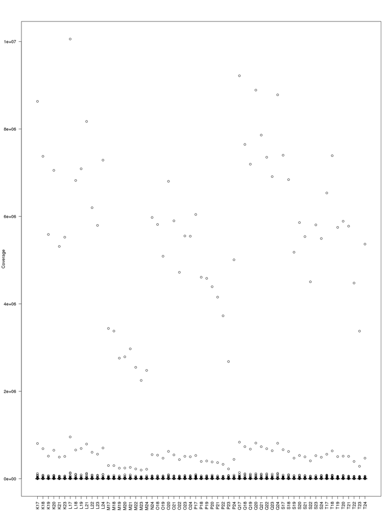

Figure 1: Sample wise coverage distributions

```r
covBoxplots(rrbs, col = "cornflowerblue", las = 2)
```

## Detection of DMRs within groups of samples

The algorithm to detect differentially methylated regions (DMRs) within two groups of samples (e.g. cancer and control) is described in detail in [Hebestreit et al. (2013)](http://dx.doi.org/10.1093/bioinformatics/btt263,doi:10.1093/bioinformatics/btt263)

The DMR detection is a five-steps approach:  
1. Definition of CpG clusters  
2. Smooth methylation data within CpG clusters  
3. Model and test group effect for each CpG site within CpG clusters  
4. Apply hierarchical testing procedure:  
4.1. Test CpG clusters for differential methylation and control weighted FDR on cluster  
4.2. Trim rejected CpG clusters and control FDR on single CpGs  
5. Define DMR boundaries

### 1. Definition of CpG clusters

In order to smooth the methylation data we first have to detect CpG clusters (regions with a high spatial density of covered CpG sites).

```r
# # Within a BSraw object clusterSites searches for agglomerations of CpG sites across all samples.
# # In a first step the data is reduced to CpG sites covered in round(perc.samples*ncol(object)) samples (here:  5 samples), these are called ’frequently covered CpG sites’.
# # In a second step regions are detected where not less than min.sites frequently covered CpG sites are sufficiantly close to each other (max.dist).
#
# rrbs.clust.unlim <- clusterSites(object = rrbs,
#                                  groups = colData(rrbs)$Genotype,
#                                  perc.samples = 0.5,
#                                  min.sites = 5,
#                                  max.dist = 500)
# # max.dist: check if output makes sense and perhaps change depending on distance of CpGs in output ##############################################
#
# # rrbs.clust.unlimis a againBSrawobject but restricted to CpG sites withinCpG clusters.  Each CpG site is assigned to a cluster.
#
# # The underlying CpG clusters can also be converted to aGRangesobject withthe start and end positions
# GRangesobject <- clusterSitesToGR(rrbs.clust.unlim)
#
# resave(rrbs.clust.unlim, GRangesobject,
#        file = "/gpfs/ts0/projects/Research_Project-191406/isabel/RRBS_new/biseq_rTg4510.RData")
```

### 2. Smooth methylation data

In the smoothing step CpG sites with high coverages get high weights. To reduce bias due to unusually high coverages we limit the coverage, e.g. to the 90% quantile.

```r
# ind.cov <- totalReads(rrbs.clust.unlim) > 0
# quant <- quantile(totalReads(rrbs.clust.unlim)[ind.cov], 0.9)
# quant
# rrbs.clust.lim <- limitCov(rrbs.clust.unlim, maxCov = quant)
#
# # We then smooth the methylation values of CpG sites within the clusters with the default bandwidthh = 80 base pairs.
# # It is possible - and recommended- to parallelize this step by settingmc.cores, to 6 cores for instance, if there are 6 available.
#
# predictedMeth <- predictMeth(object = rrbs.clust.lim, mc.cores = 6)
# # predictedMeth is a BSrel object with smoothed relative methylation levels for each CpG site within CpG clusters
#
# resave(rrbs.clust.lim, predictedMeth,
#      file = "/gpfs/ts0/projects/Research_Project-191406/isabel/RRBS_new/biseq_rTg4510.RData")
# save(predictedMeth,
#      file = "/gpfs/ts0/projects/Research_Project-191406/isabel/RRBS_new/biseq_predictedMeth_rTg4510.RData")
```

### Coverage distributions after coverage limitation

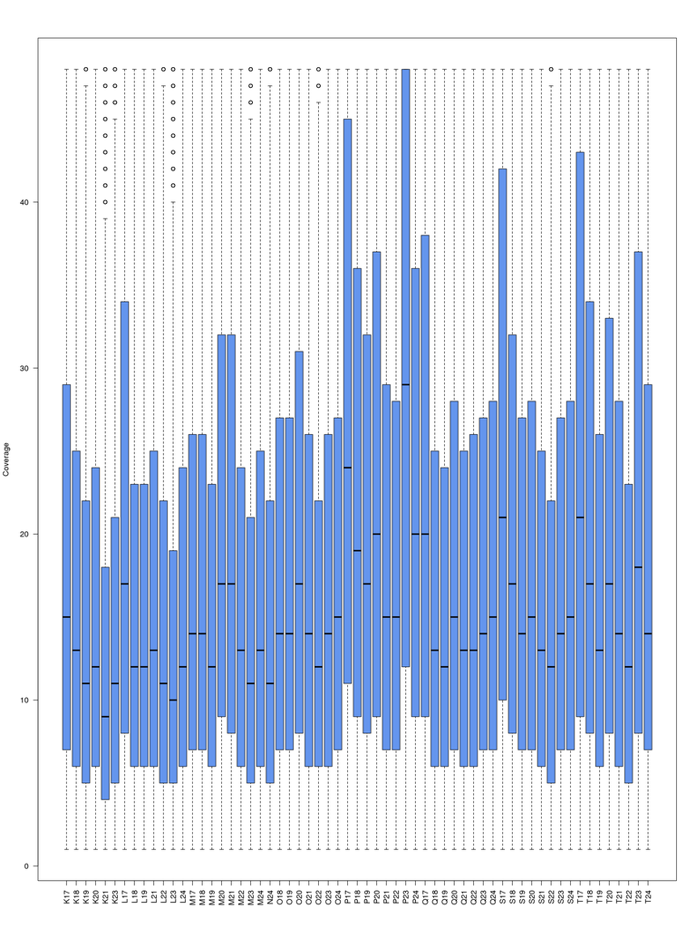

Figure 2: Sample wise coverage distributions after coverage limitation

```r
covBoxplots(rrbs.clust.lim, col = "cornflowerblue", las = 2)
```

```r
# rangesClusters <- clusterSitesToGR(rrbs.clust.unlim)
```

### Effect of the smoothing step

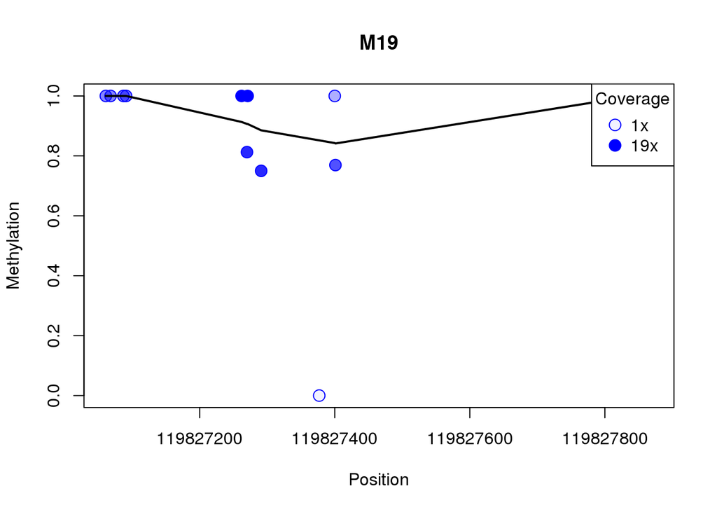

Figure 3: Raw data together with smoothed methylation levels

```r
# The effect of the smoothing step can be shown with the plotMethfunction
# rangesClusters[which(seqnames(rangesClusters) == "chr12")]
region <- GRanges(seqnames = "chr12", ranges = IRanges(start = 119827061, end = 119827870))
plotMeth(object.raw = rrbs[,16],
         object.rel = predictedMeth[,16],
         region = region,
         lwd.lines = 2,
         col.points = "blue",
         cex = 1.5)
```

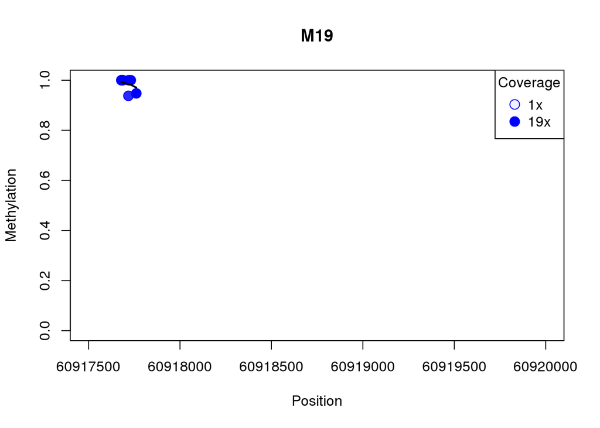

Figure 4: Raw data together with smoothed methylation levels

```r
# The effect of the smoothing step can be shown with the plotMethfunction
# rangesClusters[which(seqnames(rangesClusters) == "chr12")]
region <- GRanges(seqnames = "chr18", ranges = IRanges(start = 60917500, end = 60920000))
plotMeth(object.raw = rrbs[,16],
         object.rel = predictedMeth[,16],
         region = region,
         lwd.lines = 2,
         col.points = "blue",
         cex = 1.5)
```

Differential methylation between TG and WT for some CpG sites

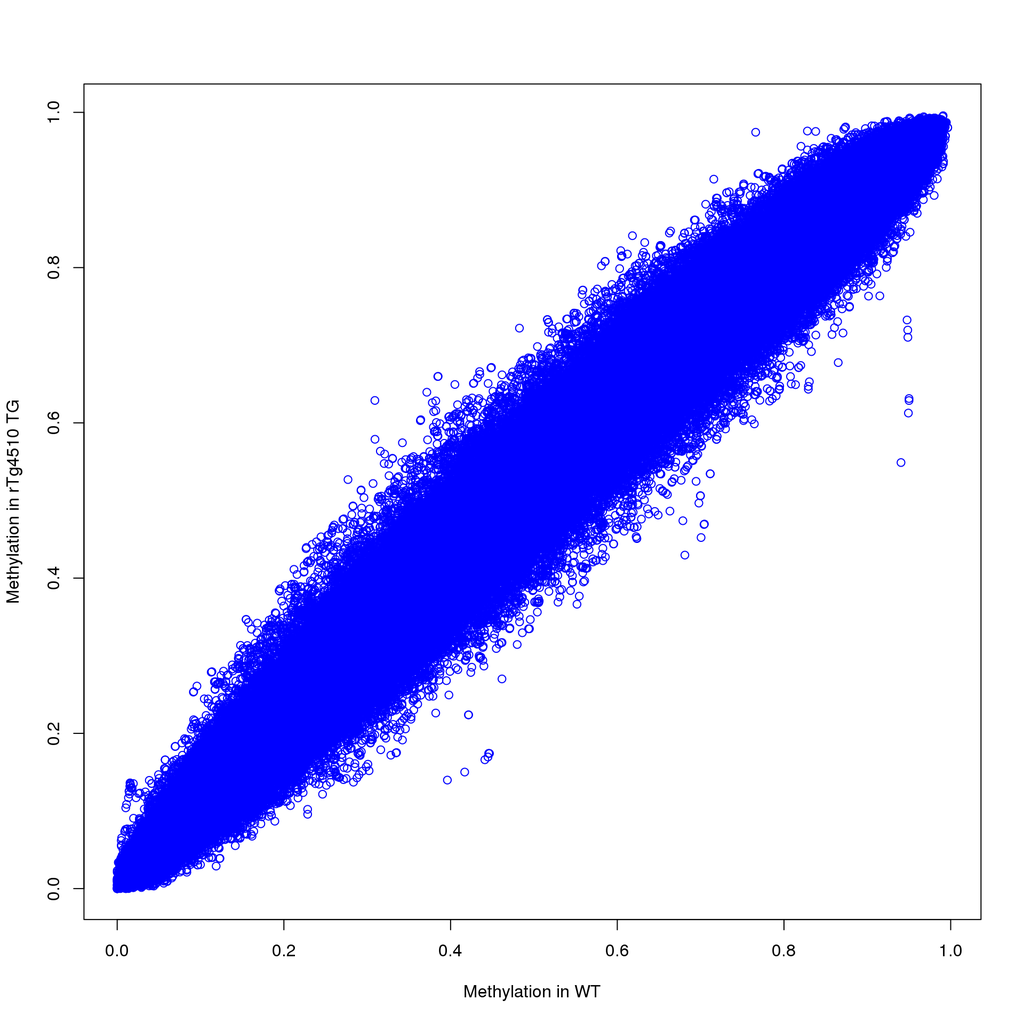

Figure 5: Smoothed methylation levels (smoothed relative methylation levels for each CpG site within CpG clusters) in TG and WT samples

```r
tg <- predictedMeth[, colData(predictedMeth)$Genotype == "TG"]
wt <- predictedMeth[, colData(predictedMeth)$Genotype == "WT"]
mean.tg <- rowMeans(methLevel(tg))
mean.wt <- rowMeans(methLevel(wt))
plot(mean.wt, mean.tg, col = "blue", xlab = "Methylation in WT", ylab = "Methylation in rTg4510 TG")
```